# A brief manual

Joshua N. Pritikin

# Overview

The **pcFactorStan** package for **R** provides convenience functions and pre-programmed **Stan** models related to analysis of paired comparison data. Its purpose is to make fitting models using Stan easy and easy to understand. **pcFactorStan** relies on the **rstan** package, which should be installed first. [See here](https://github.com/stan-dev/rstan/wiki/RStan-Getting-Started) for instructions on installing **rstan**.

One situation where a factor model might be useful is when there are people that play in tournaments of more than one game. For example, the computer player AlphaZero (Silver et al. 2018) has trained to play chess, shogi, and Go. We can take the tournament match outcome data for each of these games and find rankings among the players. We may also suspect that there is a latent board game skill that accounts for some proportion of the variance in the per-board game rankings. This proportion can be recovered by the factor model.

Our goal may be to fit a factor model, but it is necessary to build up the model step-by-step. There are essentially three models: ‘unidim’, ‘correlation’, and ‘factor’. ‘unidim’ analyzes a single item. ‘correlation’ is suitable for two or more items. Once you have vetted your items with the ‘unidim’ and ‘correlation’ models, then you can try the ‘factor’ model. There is also a special model ‘unidim_adapt’. Except for this model, the other models require scaling constants. To find appropriate scaling constants, we will fit ‘unidim_adapt’ to each item separately.

# Brief tutorial

## Physical activity flow propensity

The R code below first loads **rstan** and **pcFactorStan**. We load **loo** for extra diagnostics, and **qgraph** and **ggplot2** for visualization.

```r
library(rstan)
library(pcFactorStan)
library(loo)
library(qgraph)
library(ggplot2)
library(Matrix)
```

Next we take a peek at the data.

```r
head(phyActFlowPropensity)
```

| pa1 | pa2 | skill | predict | novelty | creative | complex | goal1 | feedback1 | chatter | waiting | body | control | present | spont | stakes | evaluated | reward |
| --- | --- | --- | --- | --- | --- | --- | --- | --- | --- | --- | --- | --- | --- | --- | --- | --- | --- |
| mountain biking | tennis | 1 | -1 | -2 | 1 | 1 | 1 | 1 | -2 | 1 | 1 | 1 | 1 | 1 | 1 | 2 | 0 |
| mountain biking | tennis | 1 | 2 | -1 | -1 | -1 | 0 | 2 | 1 | 2 | 0 | 1 | 0 | 0 | 1 | 2 | -1 |
| ice skating | running | -2 | 1 | -1 | -2 | -1 | 1 | 1 | -2 | -2 | -1 | 0 | 0 | -1 | -1 | -1 | 0 |
| climbing | rowing | -2 | 2 | -2 | -2 | -2 | 0 | -1 | -1 | -1 | -1 | -1 | -1 | 1 | 0 | 0 | 0 |
| card game | gardening | 0 | 0 | 0 | 0 | 2 | 0 | 0 | 0 | -2 | 2 | 1 | 0 | 0 | 2 | -2 | 2 |
| dance | table tennis | 0 | -2 | -1 | -1 | 0 | -1 | -1 | -1 | 0 | 0 | 0 | 0 | 0 | 0 | 0 | 1 |

These data consist of paired comparisons of 87 physical activities on 16 flow-related facets. Participants submitted two activities using free-form input. These activities were substituted into item templates. For example, Item *predict* consisted of the prompt, “How predictable is the action?” with response options:

- `A1` is much more predictable than `A2`.
- `A1` is somewhat more predictable than `A2`.
- Both offer roughly equal predictability.
- `A2` is somewhat more predictable than `A1`.
- `A2` is much more predictable than `A1`.

If the participant selected ‘golf’ and ‘running’ for activities then ‘golf’ was substituted into `A1` and ‘running’ into `A2`. Duly prepared, the item was presented and the participant asked to select the most plausible statement.

A *somewhat more* response is scored 1 or -1 and *much more* scored 2 or -2. A tie (i.e. *roughly equal*) is scored as zero. A negative value indicates > (greater than) and positive value indicates > (less than). For example, if `A1` is *golf*, `A2` is *running*, and the observed response is 2 then the endorsement is “*golf* is much less predictable than *running*.”

```r
dl <- prepData(phyActFlowPropensity[,c(paste0('pa',1:2), 'skill')])
dl$varCorrection <- 5.0
```

Next we fit the model using the `pcStan()` function, which is a wrapper for `stan()` from **rstan**. We also choose the number of chains. As is customary **Stan** procedure, the first half of each chain is used to estimate the sampler’s weight matrix (i.e. warm up) and excluded from inference.

```r
fit1 <- pcStan("unidim_adapt", data=dl)
```

A variety of diagnostics are available to check whether the sampler ran into trouble.

```r
check_hmc_diagnostics(fit1)
```

```
#>
#> Divergences:
#> 0 of 4000 iterations ended with a divergence.
#>
#> Tree depth:
#> 0 of 4000 iterations saturated the maximum tree depth of 10.
#>
#> Energy:
#> E-BFMI indicated no pathological behavior.
```

Everything looks good, but there are a few more things to check. We want $\widehat R$ < 1.015 and effective sample size greater than 100 times the number of chains (Vehtari et al., 2019).

```r
allPars <- summary(fit1, probs=c())$summary
print(min(allPars[,'n_eff']))
```

```
#> [1] 593.8
```

```r
print(max(allPars[,'Rhat']))
```

```
#> [1] 1.007
```

Again, everything looks good. If the target values were not reached then we would sample the model again with more iterations. Time for a plot,

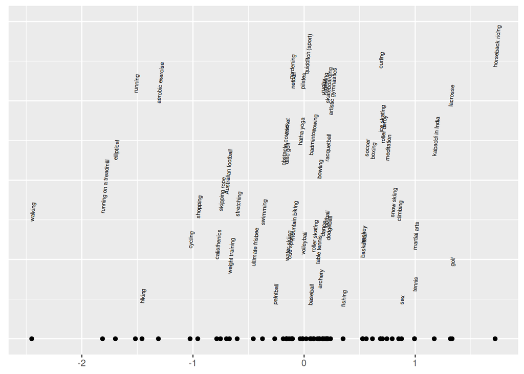

```r
theta <- summary(fit1, pars=c("theta"), probs=c())$summary[,'mean']

ggplot(data.frame(x=theta, activity=dl$nameInfo$pa, y=0.47)) +
  geom_point(aes(x=x),y=0) +
  geom_text(aes(label=activity, x=x, y=y),
            angle=85, hjust=0, size=2,
            position = position_jitter(width = 0, height = 0.4)) + ylim(0,1) +
  theme(legend.position="none",
        axis.title.x=element_blank(),
        axis.title.y=element_blank(),
        axis.text.y=element_blank(),
        axis.ticks.y=element_blank())
```

Intuitively, this seems like a fairly reasonable ranking for skill. As pretty as the plot is, the main reason that we fit this model was to find a scaling constant to produce a score variance close to 1.0,

```r
s50 <- summary(fit1, pars=c("scale"), probs=c(.5))$summary[,'50%']
print(s50)
```

```
#> [1] 0.7181
```

We use the median instead of the mean because `scale` is not likely to have a symmetric marginal posterior distribution. We obtained 0.7181, but that value is just for one item. We have to perform the same procedure for every item. Wow, that would be really tedious … if we did not have a function to do it for us! Fortunately, `calibrateItems` takes care of it and produces a table of the pertinent data,

```r
result <- calibrateItems(phyActFlowPropensity, iter=1000L)
```

```r
print(result)
```

| item | iter | divergent | treedepth | low_bfmi | n_eff | Rhat | scale | thetaVar |
| --- | --- | --- | --- | --- | --- | --- | --- | --- |
| skill | 1500 | 0 | 0 | 0 | 434.3 | 1.011 | 0.7170 | 0.8754 |
| predict | 1500 | 0 | 0 | 0 | 545.1 | 1.012 | 0.7030 | 0.8685 |
| novelty | 1000 | 0 | 0 | 0 | 418.4 | 1.012 | 0.5647 | 0.7957 |
| creative | 1000 | 0 | 0 | 0 | 439.8 | 1.007 | 0.5689 | 0.7980 |
| complex | 1500 | 0 | 0 | 0 | 578.7 | 1.010 | 0.6459 | 0.8396 |
| goal1 | 1500 | 0 | 0 | 0 | 491.8 | 1.008 | 0.0819 | 0.3676 |
| feedback1 | 1500 | 0 | 0 | 0 | 449.8 | 1.012 | 0.1756 | 0.4986 |
| chatter | 1000 | 0 | 0 | 0 | 497.1 | 1.003 | 0.2818 | 0.6026 |
| waiting | 1500 | 0 | 0 | 0 | 756.0 | 1.009 | 0.5762 | 0.8021 |
| body | 1000 | 0 | 0 | 0 | 492.2 | 1.006 | 0.4143 | 0.7030 |
| control | 1000 | 0 | 0 | 0 | 430.9 | 1.003 | 0.3453 | 0.6535 |
| present | 1000 | 0 | 0 | 0 | 533.0 | 1.004 | 0.2573 | 0.5810 |
| spont | 1000 | 0 | 0 | 0 | 567.8 | 1.008 | 0.2894 | 0.6090 |
| stakes | 1500 | 0 | 0 | 0 | 600.0 | 1.010 | 0.3002 | 0.6180 |
| evaluated | 2250 | 0 | 0 | 0 | 949.6 | 1.006 | 0.5190 | 0.7693 |
| reward | 1500 | 0 | 0 | 0 | 656.1 | 1.005 | 0.2137 | 0.5395 |

Items *goal1* and *feedback1* are prone to failure. This happens when there is no clear ranking between objects. For example, if we observe that `A<B`, `B<C`, and `C<A` then the only sensible interpretation is that `A=B=C` which can only have close to zero variance. We exclude these two items with the smallest `scale`. I requested `iter=1000L` to demonstrate how `calibrateItems` will resample the model until `n_eff` is large enough and `Rhat` small enough. As demonstrated in the *iter* column, some items needed more than 1000 samples to converge.

Next we will fit the correlation model. We exclude parameters that start with the prefix `raw`. These parameters are needed by the model, but should not be interpreted.

```r
pafp <- phyActFlowPropensity
excl <- match(c('goal1','feedback1'), colnames(pafp))
pafp <- pafp[,-excl]
dl <- prepData(pafp)
dl$scale <- result[match(dl$nameInfo$item, result$item), 'scale']
```

```r
fit2 <- pcStan("correlation", data=dl, include=FALSE, pars=c('rawTheta', 'rawThetaCorChol'))
```

```r
check_hmc_diagnostics(fit2)
```

```
#>
#> Divergences:
#> 0 of 4000 iterations ended with a divergence.
#>
#> Tree depth:
#> 0 of 4000 iterations saturated the maximum tree depth of 10.
#>
#> Energy:
#> E-BFMI indicated no pathological behavior.
```

```r
allPars <- summary(fit2, probs=0.5)$summary
print(min(allPars[,'n_eff']))
```

```
#> [1] NaN
```

```r
print(max(allPars[,'Rhat']))
```

```
#> [1] NaN
```

The HMC diagnostics look good, but … oh dear! Something is wrong with the `n_eff` and $\widehat R$. Let us look more carefully,

```r
head(allPars[order(allPars[,'sd']),])
```

```
#>               mean   se_mean        sd 50%  n_eff  Rhat
#> thetaCor[1,1]    1       NaN 0.000e+00   1    NaN   NaN
#> thetaCor[2,2]    1 9.391e-19 5.862e-17   1 3897.1 0.999
#> thetaCor[3,3]    1 1.083e-18 6.177e-17   1 3253.6 0.999
#> thetaCor[4,4]    1 4.465e-18 6.671e-17   1  223.2 0.999
#> thetaCor[5,5]    1 1.329e-18 6.743e-17   1 2574.7 0.999
#> thetaCor[7,7]    1 1.448e-18 7.711e-17   1 2837.5 0.999
```

Ah ha! It looks like all the entries of the correlation matrix are reported, including the entries that are not stochastic but are fixed to constant values. We need to filter those out to get sensible results.

```r
allPars <- allPars[allPars[,'sd'] > 1e-6,]
print(min(allPars[,'n_eff']))
```

```
#> [1] 560.5
```

```r
print(max(allPars[,'Rhat']))
```

```
#> [1] 1.008
```

Ah, much better. Now we can inspect the correlation matrix. There are many ways to visualize a correlation matrix. One of my favorite ways is to plot it using the **qgraph** package,

```r
corItemNames <- dl$nameInfo$item
tc <- summary(fit2, pars=c("thetaCor"), probs=c(.1,.5,.9))$summary
tcor <- matrix(tc, length(corItemNames), length(corItemNames))
```

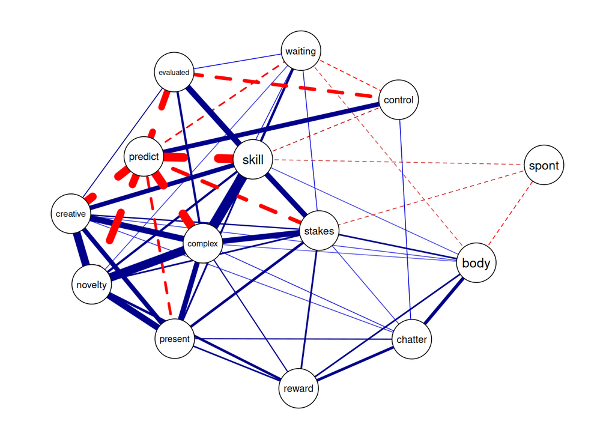

```r
tcor[sign(tc[,'10%']) != sign(tc[,'90%'])] <- 0  # delete faint edges
dimnames(tcor) <- list(corItemNames, corItemNames)
tcor <- nearPD(tcor, corr=TRUE)$mat

qgraph(tcor, layout = "spring", graph = "cor", labels=colnames(tcor),
       legend.cex = 0.3,
       cut = 0.3, maximum = 1, minimum = 0, esize = 20,
       vsize = 7, repulsion = 0.8, negDashed=TRUE, theme="colorblind")
```

Based on this plot and theoretical considerations, I decided to exclude *spont*, *control*, *evaluated*, and *waiting* from the factor model. A detailed rationale for why these items, and not others, are excluded will be presented in a forthcoming article. For now, let us focus on the mechanics of data analysis. Here are item response curves,

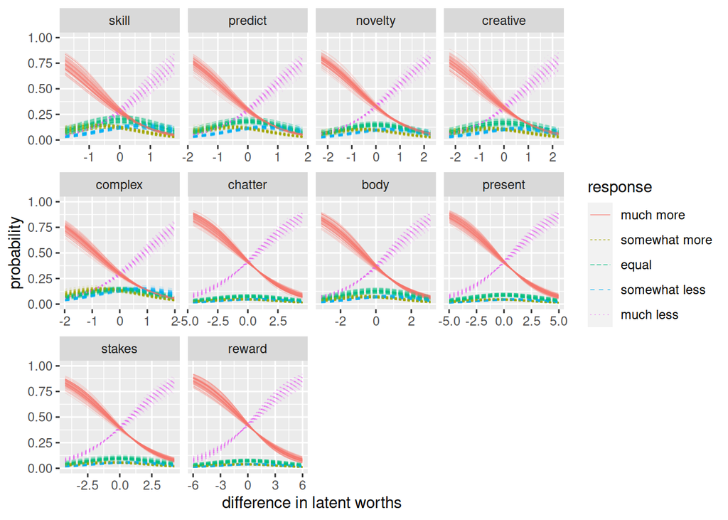

```r
df <- responseCurve(dl, fit2,
  item=setdiff(dl$nameInfo$item, c('spont','control','evaluated','waiting')),
  responseNames=c("much more","somewhat more", 'equal',
                  "somewhat less", "much less"))
ggplot(df) +
  geom_line(aes(x=worthDiff, y=prob, color=response,linetype=response,
                group=responseSample), size=.2, alpha=.2) +
  xlab("difference in latent worths") + ylab("probability") +
  ylim(0,1) + facet_wrap(~item, scales="free_x") +
  guides(color=guide_legend(override.aes=list(alpha = 1, size=1)))
```

We plot response curves from the correlation model and not the factor model because the factor model is expected to report slightly inflated discrimination estimates. These response curves are a function of the `thresholds`, `scale`, and `alpha` parameters. The ability of an item to discriminate amongst objects is partitioned into the `scale` and `alpha` parameters. Most of the information is accounted for by the `scale` parameter and the `alpha` parameter should always be estimated near 1.75. The distribution of objects is always standardized to a variance near 1.0; the `scale` parameter zooms in on the x-axis to account for the ability to make finer and finer distinctions among objects. Notice the variation in x-axis among the plots above. A detailed description of the item response model can be found in the man page for `responseCurve`.

I will fit model ‘factor_ll’ instead of ‘factor’ so I can use the **loo** package to look for outliers. We also need to take care that the data `pafp` matches, one-to-one, the data seen by Stan so we can map back from the model to the data. Hence, we update `pafp` using the usual the data cleaning sequence of `filterGraph` and `normalizeData` and pass the result to `prepCleanData`.

Up until version 1.0.2, only a single factor model was available. As of 1.1.0, the factor model supports an arbitrary number of factors and arbitrary factor-to-item structure. In this example, we will stay with the simplest factor model, a single factor that predicts all items.

```r
pafp <- pafp[,c(paste0('pa',1:2),
             setdiff(corItemNames, c('spont','control','evaluated','waiting')))]
pafp <- normalizeData(filterGraph(pafp))
dl <- prepCleanData(pafp)
dl <- prepSingleFactorModel(dl)
dl$scale <- result[match(dl$nameInfo$item, result$item), 'scale']
```

```r
fit3 <- pcStan("factor1_ll", data=dl, include=FALSE,
               pars=c('rawUnique', 'rawUniqueTheta', 'rawPerComponentVar',
           'rawFactor', 'rawLoadings', 'rawFactorProp', 'rawThreshold',
         'rawPathProp', 'rawCumTh'))
```

To check the fit diagnostics, we have to take care to examine only the parameters of interest. The factor model outputs many parameters that should not be interpreted (those that start with the prefix `raw`).

```r
check_hmc_diagnostics(fit3)
```

```
#>
#> Divergences:
#> 0 of 4000 iterations ended with a divergence.
#>
#> Tree depth:
#> 0 of 4000 iterations saturated the maximum tree depth of 10.
#>
#> Energy:
#> E-BFMI indicated no pathological behavior.
```

```r
interest <- c("threshold", "alpha", "pathProp", "factor", "residualItemCor", "lp__")

allPars <- summary(fit3, pars=interest)$summary
allPars <- allPars[allPars[,'sd'] > 1e-6,]
print(min(allPars[,'n_eff']))
```

```
#> [1] 1147
```

```r
print(max(allPars[,'Rhat']))
```

```
#> [1] 1.005
```

Looks good!

Let us see which data are the most unexpected by the model. We create a `loo` object and inspect the summary output.

```r
options(mc.cores=1)  # otherwise loo consumes too much RAM
kThreshold <- 0.1
l1 <- toLoo(fit3)
print(l1)
```

```
#>
#> Computed from 4000 by 9893 log-likelihood matrix
#>
#>          Estimate    SE
#> elpd_loo -13724.8  61.1
#> p_loo       254.8   3.5
#> looic     27449.6 122.3
#> ------
#> Monte Carlo SE of elpd_loo is 0.2.
#>
#> All Pareto k estimates are good (k < 0.5).
#> See help('pareto-k-diagnostic') for details.
```

The estimated Pareto $k$ estimates are particularly noisy due to the many activities with a small sample size. Sometimes all $k<0.5$ and sometimes not. We can look at `p_loo`, the effective number of parameters. In well behaving cases, `p_loo` is less than the sample size and the number of parameters. This looks good. There are 610 parameters just for the unique scores.

To connect $k$ statistics with observations, we pass the `loo` object to `outlierTable` and use a threshold of 0.1 instead of 0.5 to ensure that we get enough lines. Activities with small sample sizes are retained by `filterGraph` if they connect other activities because they contribute information to the model. When we look at outliers, we can limit ourselves to activities with a sample size of at least 11.

```r
pa11 <- levels(filterGraph(pafp, minDifferent=11L)$pa1)
ot <- outlierTable(dl, l1, kThreshold)
ot <- subset(ot, pa1 %in% pa11 & pa2 %in% pa11)
```

```r
print(ot[1:6,])
```

|  | pa1 | pa2 | item | pick | k |
| --- | --- | --- | --- | --- | --- |
| 11 | badminton | elliptical | creative | 0 | 0.3334 |
| 16 | badminton | cricket | creative | -1 | 0.3268 |
| 18 | cycling | aerobic exercise | present | 0 | 0.3241 |
| 32 | climbing | snow skiing | predict | -1 | 0.3042 |
| 38 | dance | swimming | reward | 1 | 0.2975 |
| 39 | badminton | volleyball | creative | 1 | 0.2937 |

```r
xx <- which(ot[,'pa1'] == 'mountain biking' & ot[,'pa2'] == 'climbing' & ot[,'item'] == 'predict' & ot[,'pick'] == -2)
```

|  | pa1 | pa2 | item | pick | k |
| --- | --- | --- | --- | --- | --- |
| 1287 | mountain biking | climbing | predict | -2 | 0.1185 |

We will take a closer look at row 1287. What does a `pick` of -2 mean? `Pick` numbers are converted to response categories by adding the number of thresholds plus one. There are two thresholds (*much* and *somewhat*) so 3 + -2 = 1. Looking back at our item response curve plot, the legend gives the response category order from top (1) to bottom (5). The first response category is *much more*. Putting it all together we obtain an endorsement of *mountain biking is much more predictable than climbing*. Specifically what about that assertion is unexpected? We can examine how other participants have responded,

```r
pafp[pafp$pa1 == ot[xx,'pa1'] & pafp$pa2 == ot[xx,'pa2'],
     c('pa1','pa2', as.character(ot[xx,'item']))]
```

```
#>                 pa1      pa2 predict
#> 563 mountain biking climbing      -2
#> 564 mountain biking climbing      -2
```

Hm, both participants agreed. Let us look a little deeper to understand why this response was unexpected.

```r
loc <- sapply(ot[xx,c('pa1','pa2','item')], unfactor)
exam <- summary(fit3, pars=paste0("theta[",loc[paste0('pa',1:2)],
                          ",", loc['item'],"]"))$summary
rownames(exam) <- c(as.character(ot[xx,'pa1']), as.character(ot[xx,'pa2']))
```

|  | mean | se_mean | sd | 2.5% | 25% | 50% | 75% | 97.5% | n_eff | Rhat |
| --- | --- | --- | --- | --- | --- | --- | --- | --- | --- | --- |
| mountain biking | -0.0588 | 0.0050 | 0.2758 | -0.6005 | -0.2490 | -0.0604 | 0.1373 | 0.4645 | 2991 | 1.000 |
| climbing | -0.6752 | 0.0065 | 0.3662 | -1.4165 | -0.9144 | -0.6651 | -0.4290 | 0.0260 | 3150 | 1.001 |

Here we find that mountain biking was estimated 0.6164 units more predictable than climbing. I guess this difference was expected to be larger. What sample sizes are associated with these activities?

```r
sum(c(pafp$pa1 == ot[xx,'pa1'], pafp$pa2 == ot[xx,'pa1']))
```

```
#> [1] 25
```

```r
sum(c(pafp$pa1 == ot[xx,'pa2'], pafp$pa2 == ot[xx,'pa2']))
```

```
#> [1] 13
```

Hm, the predictability 95% uncertainty interval for climbing is from -1.4165 to 0.026. So there is little information. We could continue our investigation by looking at which responses justified these *predict* estimates. However, let us move on and plot the marginal posterior distributions of the factor proportions. Typical jargon is *factor loadings*, but *proportion* is preferable since the scale is arbitrary and standardized.

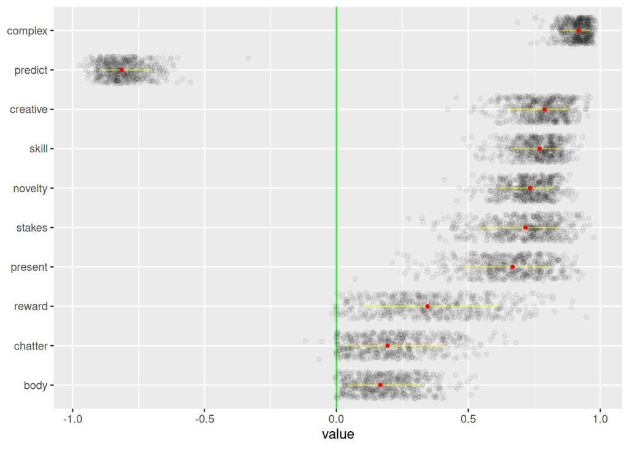

```r
pi <- parInterval(fit3, 'pathProp', dl$nameInfo$item, label='item')
pi <- pi[order(abs(pi$M)),]

ggplot(pi) +
  geom_vline(xintercept=0, color="green") +
  geom_jitter(data=parDistributionFor(fit3, pi),
              aes(value, item), height = 0.35, alpha=.05) +
  geom_segment(aes(y=item, yend=item, x=L, xend=U),
               color="yellow", alpha=.5) +
  geom_point(aes(x=M, y=item), color="red", size=1) +
  theme(axis.title.y=element_blank())
```

Finally, we can plot the factor scores.

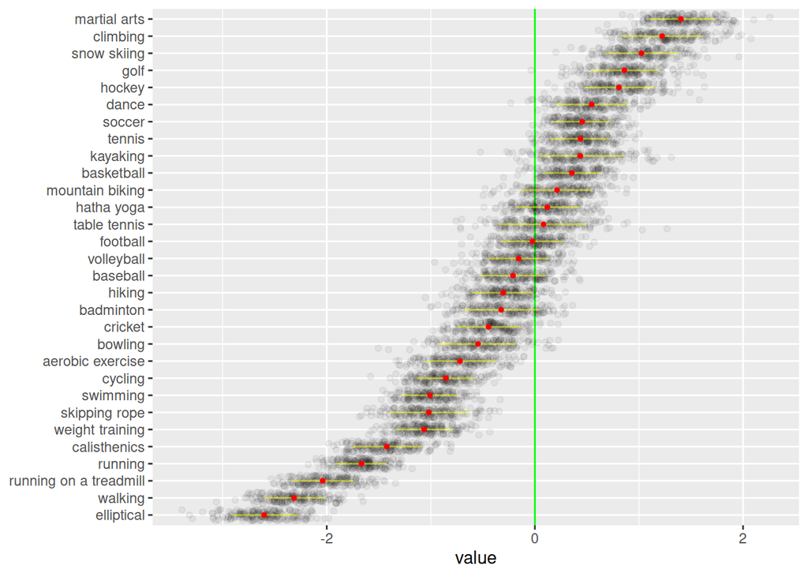

```r
pick <- paste0('factor[',match(pa11, dl$nameInfo$pa),',1]')
pi <- parInterval(fit3, pick, pa11, label='activity')
pi <- pi[order(pi$M),]

ggplot(pi) +
  geom_vline(xintercept=0, color="green") +
  geom_jitter(data=parDistributionFor(fit3, pi, samples=200),
              aes(value, activity), height = 0.35, alpha=.05) +
  geom_segment(aes(y=activity, yend=activity, x=L, xend=U),
               color="yellow", alpha=.5) +
  geom_point(aes(x=M, y=activity), color="red", size=1) +
  theme(axis.title.y=element_blank())
```

If this factor model is a good fit to the data then the residual item activity scores should be uncorrelated. Let us examine the residual item correlation matrix.

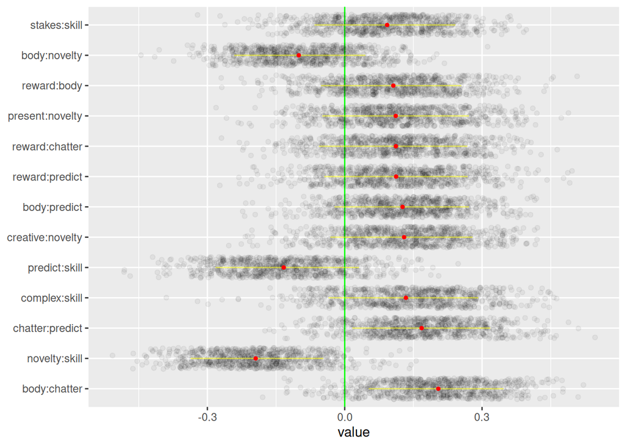

```r
m <- matrix(apply(expand.grid(r=1:dl$NITEMS, c=1:dl$NITEMS), 1,
      function(x) paste0("residualItemCor[",x['r'],",",x['c'],"]")),
      dl$NITEMS, dl$NITEMS)
n <- matrix(apply(expand.grid(r=dl$nameInfo$item, c=dl$nameInfo$item), 1,
                  function(x) paste0(x['r'],":",x['c'])),
            dl$NITEMS, dl$NITEMS)
pi <- parInterval(fit3, m[lower.tri(m)], n[lower.tri(n)], label='cor')
pi <- pi[abs(pi$M) > .08,]
pi <- pi[order(-abs(pi$M)),]
ggplot(pi) +
  geom_vline(xintercept=0, color="green") +
  geom_jitter(data=parDistributionFor(fit3, pi, samples=800),
              aes(value, cor), height = 0.35, alpha=.05) +
  geom_segment(aes(y=cor, yend=cor, x=L, xend=U),
               color="yellow", alpha=.5) +
  geom_point(aes(x=M, y=cor), color="red", size=1) +
  theme(axis.title.y=element_blank())
```

Many survey measures are going to exhibit some faint correlations of this nature. Residual correlations can suggest items that could benefit from refinement. Item *chatter* is involved in relatively high residual correlations. Thought might be give to splitting this item or rewording it.

And there you have it. If you have not done so already, go find a dojo and commence study of martial arts!

# Technical notes

If you read through the **Stan** models included with this package, you will find some variables prefixed with `raw`. These are special variables internal to the model. In particular, you should not try to evaluate the $\widehat R$ or effective sample size of `raw` parameters. These parameters are best excluded from the sampling output.

## Latent worths

Latent worths are estimated by `theta` parameters. `theta` is always standard normally distributed.

## Thresholds

Thresholds are parameterized as a proportion with distribution `Beta(1.1, 2.0)`. The shape of this prior is fairly arbitrary. `Uniform(0,1)` also works in many cases. There is usually plenty of information available to estimate thresholds accurately. To convert from a proportion to threshold units, the following formula is employed, `rawThreshold * (max(theta) - min(theta))`.

## Unidim adapt

This model is fairly robust; priors are unlikely to need tweaking. The ‘unidim_adapt’ model has a `varCorrection` constant that is used to calibrate the `scale`. For all other models, the per-item `scale` must be supplied as data.

## Alpha

All models except ‘unidim_adapt’ estimate the item discrimination parameter `alpha`. A `normal(1.749, alphaScalePrior)` prior is used with `alphaScalePrior` set to 0.2 by default. `alpha` must be positive so the normal distribution is truncated at zero. The distribution is centered at 1.749 because this allows the logistic to approximate the standard normal cumulative distribution (Savalei, 2006). We need to estimate `alpha` because `scale` is entered as a constant and we need to account for the stochastic uncertainty in the item’s ability to discriminate objects.

## Correlation

The correlation matrix uses a `lkj_corr(corLKJPrior)` prior with `corLKJPrior` set to 2.5 by default. It may be necessary to increase the prior if divergences are observed.

## Factor

`factor` scores are standard normally distributed. `pathProp` is shaped by two priors that act on different parts of the distribution. `rawLoadings` are distributed `beta(propShape, propShape)` with `propShape` set to 4.0 by default. `rawLoadings` has an indirect influence on `pathProp`. The quantity `2*rawLoadings-1` is used to scale the factor scores, but `pathProp` is computed based on Equation 3 of Gelman et al. (in press). `pathProp` is a signed proportion bounded between -1 and 1. `pathProp` is additionally constrained by prior `normal(logit(0.5 + pathProp/2), pathScalePrior)` where `pathScalePrior` is set to 1.2 by default. This prevents extreme factor proportions (i.e. |pathProp|>.95). The purpose of `propShape` is to nudge `rawLoadings` toward zero. If may be necessary to increase `propShape` if divergences are observed.

If you have more than one factor then `Psi` is available to estimate correlations among factors. The prior on entries of `Psi` is `normal(logit(0.5 + Psi/2), psiScalePrior)`. It may be necessary to reduce `psiScalePrior` toward zero if factors are highly correlated.

The idea of putting a prior on `pathProp` was inspired by Gelman (2019, Aug 23).

# References

Gelman, A. (2019, Aug 23). Yes, you can include prior information on quantities of interest, not just on parameters in your model [Blog post]. Retrieved from https://statmodeling.stat.columbia.edu/2019/08/23/yes-you-can-include-prior-information-on-quantities-of-interest-not-just-on-parameters-in-your-model/.

Gelman, A., Goodrich, B., Gabry, J., & Vehtari, A. (in press). R-squared for Bayesian regression models. *The American Statistician.*

Savalei, V. (2006). Logistic approximation to the normal: The KL rationale. *Psychometrika, 71*(4), 763–767.

Silver, D., Hubert, T., Schrittwieser, J., Antonoglou, I., Lai, M., Guez, A., … & Lillicrap, T. (2018). A general reinforcement learning algorithm that masters chess, shogi, and Go through self-play. Science, 362(6419), 1140-1144.

Vehtari, A., Gelman, A., Simpson, D., Carpenter, B., & Bürkner, P. C. (2019). Rank-normalization, folding, and localization: An improved $\widehat R$ for assessing convergence of MCMC. *arXiv preprint* arXiv:1903.08008.